# IODS course project

# Logistic regression

```r
setwd("~/yhis-kouluhommat/IODS-project")

library(ggplot2)
library(dplyr)
library(GGally)
library(MASS)
library(tidyr)
library(boot)
library(corrplot)
```

**Data**

```r
alc <- read.csv("alc.csv", header = T)

str(alc)
```

```
## 'data.frame':    382 obs. of  36 variables:
##  $ X         : int  1 2 3 4 5 6 7 8 9 10 ...
##  $ school    : Factor w/ 2 levels "GP","MS": 1 1 1 1 1 1 1 1 1 1 ...
##  $ sex       : Factor w/ 2 levels "F","M": 1 1 1 1 1 2 2 1 2 2 ...
##  $ age       : int  18 17 15 15 16 16 16 17 15 15 ...
##  $ address   : Factor w/ 2 levels "R","U": 2 2 2 2 2 2 2 2 2 2 ...
##  $ famsize   : Factor w/ 2 levels "GT3","LE3": 1 1 2 1 1 2 2 1 2 1 ...
##  $ Pstatus   : Factor w/ 2 levels "A","T": 1 2 2 2 2 2 2 1 1 2 ...
##  $ Medu      : int  4 1 1 4 3 4 2 4 3 3 ...
##  $ Fedu      : int  4 1 1 2 3 3 2 4 2 4 ...
##  $ Mjob      : Factor w/ 5 levels "at_home","health",..: 1 1 1 2 3 4 3 3 4 3 ...
##  $ Fjob      : Factor w/ 5 levels "at_home","health",..: 5 3 3 4 3 3 3 5 3 3 ...
##  $ reason    : Factor w/ 4 levels "course","home",..: 1 1 3 2 2 4 2 2 2 2 ...
##  $ nursery   : Factor w/ 2 levels "no","yes": 2 1 2 2 2 2 2 2 2 2 ...
##  $ internet  : Factor w/ 2 levels "no","yes": 1 2 2 2 1 2 2 1 2 2 ...
```

[output cut: 22 more lines]

This data approach student achievement in secondary education of two Portuguese schools. The data attributes include student grades, demographic, social and school related features and it was collected by using school reports and questionnaires. The dependent variable in the present report was risky alcohol consumption. First, general level of alcohol consumption was defined as the average of weekday and weekend alcohol consumption (both measured on scale from 1 - very low to 5 - very high). Individual was defined as high-level alcohol user if their averge alcohol consumption was greater than 2.  
The main explanatory variables are sex (male, female), quality of family relationships (numeric: from 1 - very bad to 5 - excellent), mother’s education (numeric: 0 - none, 1 - primary education - 4th grade, 2 - 5th to 9th grade, 3 - secondary education or 4 - higher education), going out with friends (numeric: from 1 - very low to 5 - very high).

**The hypotheses of the present report are as follows:**

1. Male sex is associatied with higher risk of high alcohol consumption
2. Better familiy relationships are protective against high alcohol consumption
3. Mother’s low education predicts higher risk of high alcohol consumption
4. Going out with friends frequently predicts higher risk of high alcohol consumption

Prepararing variables

```r
keep_columns <- c("sex","Medu","famrel", "goout", "high_use")

data <- dplyr::select(alc, one_of(keep_columns))

str(data)
```

```
## 'data.frame':    382 obs. of  5 variables:
##  $ sex     : Factor w/ 2 levels "F","M": 1 1 1 1 1 2 2 1 2 2 ...
##  $ Medu    : int  4 1 1 4 3 4 2 4 3 3 ...
##  $ famrel  : int  4 5 4 3 4 5 4 4 4 5 ...
##  $ goout   : int  4 3 2 2 2 2 4 4 2 1 ...
##  $ high_use: logi  FALSE FALSE TRUE FALSE FALSE FALSE ...
```

**Variable frequencies**

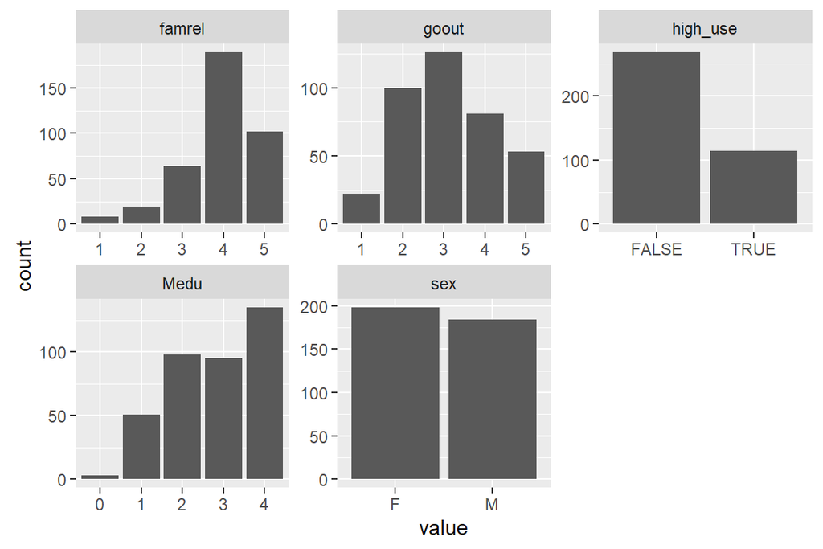

```r
gather(data) %>% ggplot(aes(value)) + facet_wrap("key", scales = "free") + geom_bar()
```

**Associations between dependent and independent variables**  
Family relationships

```r
data %>% group_by(sex, high_use) %>% summarise(count = n(), mean_grade=mean(famrel))
```

```
## Source: local data frame [4 x 4]
## Groups: sex [?]
##
##      sex high_use count mean_grade
##   (fctr)    (lgl) (int)      (dbl)
## 1      F    FALSE   156   3.910256
## 2      F     TRUE    42   3.761905
## 3      M    FALSE   112   4.133929
## 4      M     TRUE    72   3.791667
```

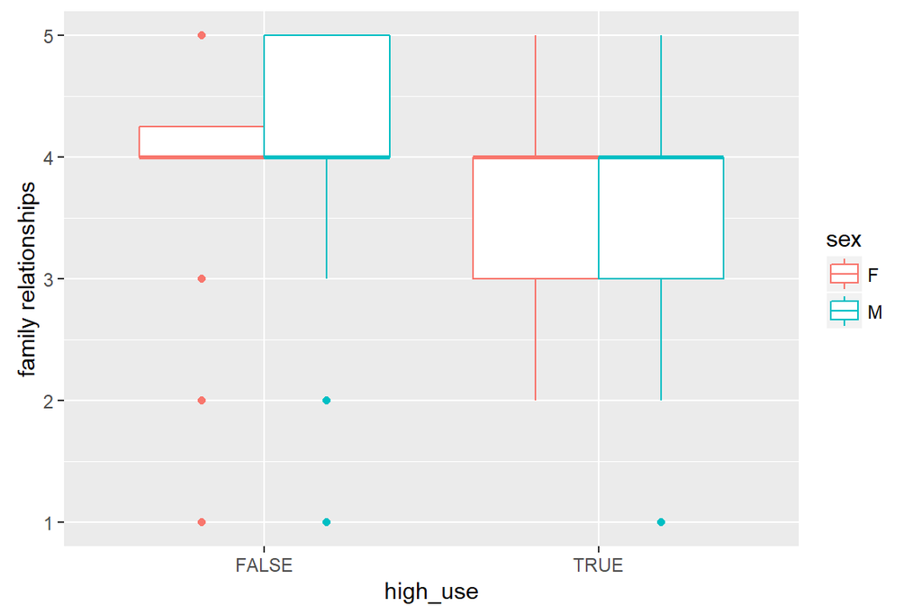

```r
g1 <- ggplot(data, aes(x = high_use, y = famrel, col=sex))


g1 + geom_boxplot() + ylab("family relationships")
```

Above, the results of group mean comparisons and the box plot figure show that the means in family relationship quality were very close to one another in high use and non-high use groups. However, the variance was much larger in the high use group, indicating that in there was more variability in this group in the family relationship quality.

Going out with friends

```r
data %>% group_by(sex, high_use) %>% summarise(count = n(), mean_grade=mean(goout))
```

```
## Source: local data frame [4 x 4]
## Groups: sex [?]
##
##      sex high_use count mean_grade
##   (fctr)    (lgl) (int)      (dbl)
## 1      F    FALSE   156   2.955128
## 2      F     TRUE    42   3.357143
## 3      M    FALSE   112   2.714286
## 4      M     TRUE    72   3.930556
```

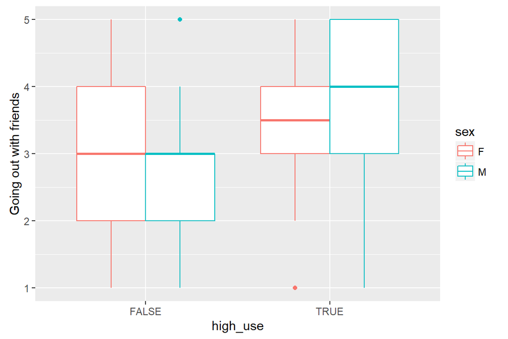

```r
g1 <- ggplot(data, aes(x = high_use, y = goout, col=sex))


g1 + geom_boxplot() + ylab("Going out with friends")
```

The group mean comparisons and the box plot figure show that there appears to be mean differences in the frequency of going out with friends. The group that uses more alcohol goes out with friends more frequently.

Mother’s education

```r
data %>% group_by(sex, high_use) %>% summarise(count = n(), mean_grade=mean(Medu))
```

```
## Source: local data frame [4 x 4]
## Groups: sex [?]
##
##      sex high_use count mean_grade
##   (fctr)    (lgl) (int)      (dbl)
## 1      F    FALSE   156   2.673077
## 2      F     TRUE    42   2.785714
## 3      M    FALSE   112   2.973214
## 4      M     TRUE    72   2.847222
```

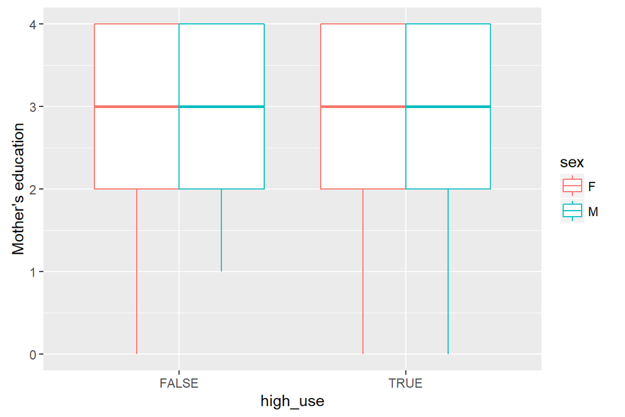

```r
g1 <- ggplot(data, aes(x = high_use, y = Medu, col=sex))


g1 + geom_boxplot() + ylab("Mother's education")
```

There seems to be no clear differences between high risk and non-high risk alcohol users regarding mother’s education.

**Logistic regression**

```r
m <- glm(high_use ~ sex + famrel + goout + Medu, data = alc, family = "binomial")
summary(m)
```

```
##
## Call:
## glm(formula = high_use ~ sex + famrel + goout + Medu, family = "binomial",
##     data = alc)
##
## Deviance Residuals:
##     Min       1Q   Median       3Q      Max
## -1.5528  -0.7881  -0.5278   0.8438   2.5588
##
## Coefficients:
##             Estimate Std. Error z value Pr(>|z|)
## (Intercept)  -2.1725     0.7062  -3.076 0.002095 **
## sexM          0.9476     0.2526   3.751 0.000176 ***
## famrel       -0.4148     0.1388  -2.989 0.002803 **
## goout         0.8013     0.1217   6.584 4.58e-11 ***
## Medu         -0.0682     0.1139  -0.599 0.549340
## ---
## Signif. codes:  0 '***' 0.001 '**' 0.01 '*' 0.05 '.' 0.1 ' ' 1
##
## (Dispersion parameter for binomial family taken to be 1)
##
##     Null deviance: 465.68  on 381  degrees of freedom
## Residual deviance: 393.44  on 377  degrees of freedom
## AIC: 403.44
##
## Number of Fisher Scoring iterations: 4
```

Computing Odds Ratios

```r
OR <- coef(m) %>% exp
CI <- confint(m) %>% exp
cbind(OR, CI)
```

```
##                    OR     2.5 %    97.5 %
## (Intercept) 0.1138880 0.0273881 0.4400122
## sexM        2.5794294 1.5810282 4.2643295
## famrel      0.6604684 0.5014022 0.8655158
## goout       2.2285055 1.7673133 2.8509142
## Medu        0.9340696 0.7470098 1.1687385
```

The logistic regression model shows that all variables but mother’s education had statistically significant relationsips with alcohol consumption (p-value less than 0.05).

Boys, compared to girls, had 2.6 times the odds of being a high risk alcohol user. This result provides support for the first hypothesis of gender differences in high risk alcohol use.

Increase in going out with friends increased the odds of high risk alcohol use. This is also in line with the original hypothesis.

Further, as relationship quality with family decreased, the odds of high risk increased. The result supports the hypothesis that worse family relationships would increase the risk of alcohol consumption.

**Model performance**

Family relationship

```r
probabilities <- predict(m, type = "response")
data <- mutate(data, probability = probabilities)
data <- mutate(data, prediction = probability > 0.5)
dplyr::select(data, famrel, goout, sex, high_use, probability, prediction) %>% tail(10)
```

```
##     famrel goout sex high_use probability prediction
## 373      4     2   M    FALSE  0.20591330      FALSE
## 374      5     3   M     TRUE  0.23724833      FALSE
## 375      5     3   F    FALSE  0.12142711      FALSE
## 376      4     3   F    FALSE  0.15438857      FALSE
## 377      5     2   F    FALSE  0.05839718      FALSE
## 378      4     4   F    FALSE  0.30342270      FALSE
## 379      2     2   F    FALSE  0.18729340      FALSE
## 380      1     1   F    FALSE  0.13537830      FALSE
## 381      2     5   M     TRUE  0.85163207       TRUE
## 382      4     1   M     TRUE  0.09216541      FALSE
```

```r
table(high_use = data$high_use, prediction = data$prediction)
```

```
##         prediction
## high_use FALSE TRUE
##    FALSE   247   21
##    TRUE     65   49
```

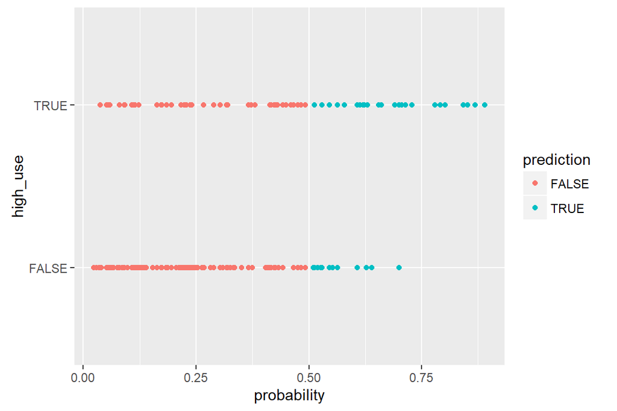

```r
g <- ggplot(data, aes(x = probability, y = high_use, col = prediction))
g + geom_point()
```

```r
table(high_use = data$high_use, prediction = data$prediction) %>% prop.table() %>% addmargins()
```

```
##         prediction
## high_use      FALSE       TRUE        Sum
##    FALSE 0.64659686 0.05497382 0.70157068
##    TRUE  0.17015707 0.12827225 0.29842932
##    Sum   0.81675393 0.18324607 1.00000000
```

Average number of wrong predictions in the (training) data & 10-fold cross-validation

```r
loss_func <- function(class, prob) {
  n_wrong <- abs(class - prob) > 0.5
  mean(n_wrong)
}

loss_func(class = data$high_use, prob = data$probability)
```

```
## [1] 0.2251309
```

```r
cv <- cv.glm(data = data, cost = loss_func, glmfit = m, K = 10)

cv$delta[1]
```

```
## [1] 0.2356021
```

The error of 0.24 was found in the 10-fold cross-validation, which is slightly better than the 0.26 error in the DataCamp exercises.

# Clustering and classification

```r
setwd("~/yhis-kouluhommat/IODS-project")

library(ggplot2)
library(dplyr)
library(GGally)
library(MASS)
library(tidyr)
library(boot)
library(corrplot)
```

```r
data(Boston)
str(Boston)
```

```
## 'data.frame':    506 obs. of  14 variables:
##  $ crim   : num  0.00632 0.02731 0.02729 0.03237 0.06905 ...
##  $ zn     : num  18 0 0 0 0 0 12.5 12.5 12.5 12.5 ...
##  $ indus  : num  2.31 7.07 7.07 2.18 2.18 2.18 7.87 7.87 7.87 7.87 ...
##  $ chas   : int  0 0 0 0 0 0 0 0 0 0 ...
##  $ nox    : num  0.538 0.469 0.469 0.458 0.458 0.458 0.524 0.524 0.524 0.524 ...
##  $ rm     : num  6.58 6.42 7.18 7 7.15 ...
##  $ age    : num  65.2 78.9 61.1 45.8 54.2 58.7 66.6 96.1 100 85.9 ...
##  $ dis    : num  4.09 4.97 4.97 6.06 6.06 ...
##  $ rad    : int  1 2 2 3 3 3 5 5 5 5 ...
##  $ tax    : num  296 242 242 222 222 222 311 311 311 311 ...
##  $ ptratio: num  15.3 17.8 17.8 18.7 18.7 18.7 15.2 15.2 15.2 15.2 ...
##  $ black  : num  397 397 393 395 397 ...
##  $ lstat  : num  4.98 9.14 4.03 2.94 5.33 ...
##  $ medv   : num  24 21.6 34.7 33.4 36.2 28.7 22.9 27.1 16.5 18.9 ...
```

```r
summary(Boston)
```

```
##       crim                zn             indus            chas
##  Min.   : 0.00632   Min.   :  0.00   Min.   : 0.46   Min.   :0.00000
##  1st Qu.: 0.08204   1st Qu.:  0.00   1st Qu.: 5.19   1st Qu.:0.00000
##  Median : 0.25651   Median :  0.00   Median : 9.69   Median :0.00000
##  Mean   : 3.61352   Mean   : 11.36   Mean   :11.14   Mean   :0.06917
##  3rd Qu.: 3.67708   3rd Qu.: 12.50   3rd Qu.:18.10   3rd Qu.:0.00000
##  Max.   :88.97620   Max.   :100.00   Max.   :27.74   Max.   :1.00000
##       nox               rm             age              dis
##  Min.   :0.3850   Min.   :3.561   Min.   :  2.90   Min.   : 1.130
##  1st Qu.:0.4490   1st Qu.:5.886   1st Qu.: 45.02   1st Qu.: 2.100
##  Median :0.5380   Median :6.208   Median : 77.50   Median : 3.207
##  Mean   :0.5547   Mean   :6.285   Mean   : 68.57   Mean   : 3.795
##  3rd Qu.:0.6240   3rd Qu.:6.623   3rd Qu.: 94.08   3rd Qu.: 5.188
##  Max.   :0.8710   Max.   :8.780   Max.   :100.00   Max.   :12.127
##       rad              tax           ptratio          black
##  Min.   : 1.000   Min.   :187.0   Min.   :12.60   Min.   :  0.32
##  1st Qu.: 4.000   1st Qu.:279.0   1st Qu.:17.40   1st Qu.:375.38
##  Median : 5.000   Median :330.0   Median :19.05   Median :391.44
##  Mean   : 9.549   Mean   :408.2   Mean   :18.46   Mean   :356.67
##  3rd Qu.:24.000   3rd Qu.:666.0   3rd Qu.:20.20   3rd Qu.:396.23
##  Max.   :24.000   Max.   :711.0   Max.   :22.00   Max.   :396.90
##      lstat            medv
##  Min.   : 1.73   Min.   : 5.00
##  1st Qu.: 6.95   1st Qu.:17.02
##  Median :11.36   Median :21.20
##  Mean   :12.65   Mean   :22.53
##  3rd Qu.:16.95   3rd Qu.:25.00
##  Max.   :37.97   Max.   :50.00
```

In the Boston dataset, there are 506 observations and 14 variables, which have been studied in relation to housing values in suburbs of Boston, e.g. crime rate, taxation, population composition, and accessibility to radial highways.

**Variable frequencies and correlations**

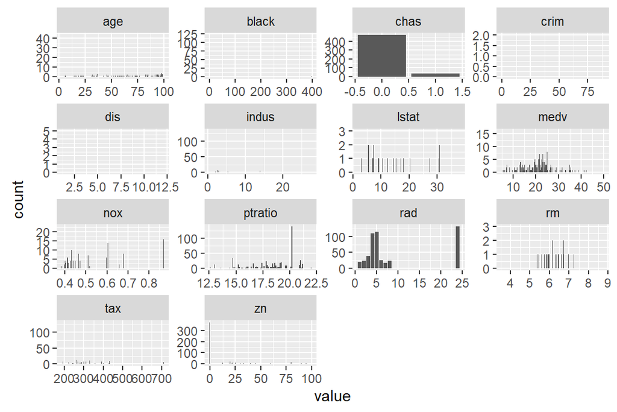

```r
gather(Boston) %>% ggplot(aes(value)) + facet_wrap("key", scales = "free") + geom_bar()
```

Crime rate (crim) average is 3.6 per capita. However, the distribution is rather skewed, since the maximum value is 88. Mean age of the sample is approximately 68 years. The tax rate variable is also very skewed to the right, i.e. the mode value of property-tax rate per $10,000 is 650, but there is a low variablitiy on the low end as well (200-400). Similar distribution is seen in the accessibility to radial highways (rad variable)

```r
# calculate the correlation matrix and round it
cor_matrix<-cor(Boston) %>% round(digits=2)

# print the correlation matrix
cor_matrix
```

```
##          crim    zn indus  chas   nox    rm   age   dis   rad   tax
## crim     1.00 -0.20  0.41 -0.06  0.42 -0.22  0.35 -0.38  0.63  0.58
## zn      -0.20  1.00 -0.53 -0.04 -0.52  0.31 -0.57  0.66 -0.31 -0.31
## indus    0.41 -0.53  1.00  0.06  0.76 -0.39  0.64 -0.71  0.60  0.72
## chas    -0.06 -0.04  0.06  1.00  0.09  0.09  0.09 -0.10 -0.01 -0.04
## nox      0.42 -0.52  0.76  0.09  1.00 -0.30  0.73 -0.77  0.61  0.67
## rm      -0.22  0.31 -0.39  0.09 -0.30  1.00 -0.24  0.21 -0.21 -0.29
## age      0.35 -0.57  0.64  0.09  0.73 -0.24  1.00 -0.75  0.46  0.51
## dis     -0.38  0.66 -0.71 -0.10 -0.77  0.21 -0.75  1.00 -0.49 -0.53
## rad      0.63 -0.31  0.60 -0.01  0.61 -0.21  0.46 -0.49  1.00  0.91
## tax      0.58 -0.31  0.72 -0.04  0.67 -0.29  0.51 -0.53  0.91  1.00
## ptratio  0.29 -0.39  0.38 -0.12  0.19 -0.36  0.26 -0.23  0.46  0.46
## black   -0.39  0.18 -0.36  0.05 -0.38  0.13 -0.27  0.29 -0.44 -0.44
## lstat    0.46 -0.41  0.60 -0.05  0.59 -0.61  0.60 -0.50  0.49  0.54
## medv    -0.39  0.36 -0.48  0.18 -0.43  0.70 -0.38  0.25 -0.38 -0.47
##         ptratio black lstat  medv
## crim       0.29 -0.39  0.46 -0.39
## zn        -0.39  0.18 -0.41  0.36
## indus      0.38 -0.36  0.60 -0.48
## chas      -0.12  0.05 -0.05  0.18
## nox        0.19 -0.38  0.59 -0.43
## rm        -0.36  0.13 -0.61  0.70
## age        0.26 -0.27  0.60 -0.38
## dis       -0.23  0.29 -0.50  0.25
## rad        0.46 -0.44  0.49 -0.38
## tax        0.46 -0.44  0.54 -0.47
## ptratio    1.00 -0.18  0.37 -0.51
## black     -0.18  1.00 -0.37  0.33
## lstat      0.37 -0.37  1.00 -0.74
## medv      -0.51  0.33 -0.74  1.00
```

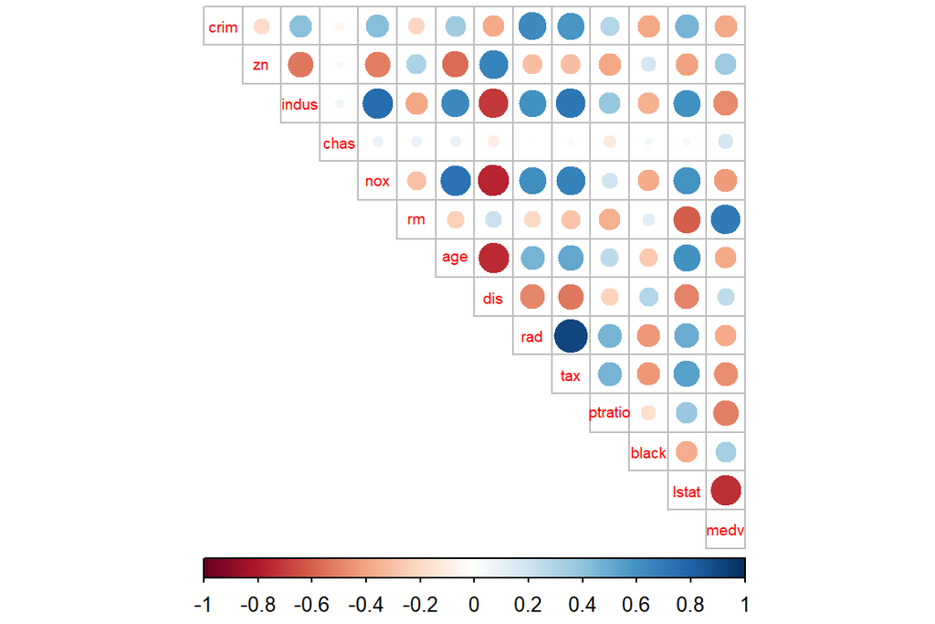

```r
# visualize the correlation matrix
corrplot(cor_matrix, method="circle", type="upper", cl.pos = "b", tl.pos = "d",tl.cex = 0.6)
```

Correlation matrix shows several large negative and positive associations. For example, the correlation between crime rate and accessibility to radial highways and tax-rate are 0.63 and 0.58 respectively. There is a strong negative correlation between proportion of non-retail business acres per town and weighted mean of distances to five Boston employment centres, and lower status of the population and median value of homes.

```r
# center and standardize variables
boston_scaled <- scale(Boston)

# summaries of the scaled variables
summary(boston_scaled)
```

```
##       crim                 zn               indus
##  Min.   :-0.419367   Min.   :-0.48724   Min.   :-1.5563
##  1st Qu.:-0.410563   1st Qu.:-0.48724   1st Qu.:-0.8668
##  Median :-0.390280   Median :-0.48724   Median :-0.2109
##  Mean   : 0.000000   Mean   : 0.00000   Mean   : 0.0000
##  3rd Qu.: 0.007389   3rd Qu.: 0.04872   3rd Qu.: 1.0150
##  Max.   : 9.924110   Max.   : 3.80047   Max.   : 2.4202
##       chas              nox                rm               age
##  Min.   :-0.2723   Min.   :-1.4644   Min.   :-3.8764   Min.   :-2.3331
##  1st Qu.:-0.2723   1st Qu.:-0.9121   1st Qu.:-0.5681   1st Qu.:-0.8366
##  Median :-0.2723   Median :-0.1441   Median :-0.1084   Median : 0.3171
##  Mean   : 0.0000   Mean   : 0.0000   Mean   : 0.0000   Mean   : 0.0000
##  3rd Qu.:-0.2723   3rd Qu.: 0.5981   3rd Qu.: 0.4823   3rd Qu.: 0.9059
##  Max.   : 3.6648   Max.   : 2.7296   Max.   : 3.5515   Max.   : 1.1164
##       dis               rad               tax             ptratio
##  Min.   :-1.2658   Min.   :-0.9819   Min.   :-1.3127   Min.   :-2.7047
##  1st Qu.:-0.8049   1st Qu.:-0.6373   1st Qu.:-0.7668   1st Qu.:-0.4876
##  Median :-0.2790   Median :-0.5225   Median :-0.4642   Median : 0.2746
##  Mean   : 0.0000   Mean   : 0.0000   Mean   : 0.0000   Mean   : 0.0000
##  3rd Qu.: 0.6617   3rd Qu.: 1.6596   3rd Qu.: 1.5294   3rd Qu.: 0.8058
##  Max.   : 3.9566   Max.   : 1.6596   Max.   : 1.7964   Max.   : 1.6372
##      black             lstat              medv
##  Min.   :-3.9033   Min.   :-1.5296   Min.   :-1.9063
##  1st Qu.: 0.2049   1st Qu.:-0.7986   1st Qu.:-0.5989
##  Median : 0.3808   Median :-0.1811   Median :-0.1449
##  Mean   : 0.0000   Mean   : 0.0000   Mean   : 0.0000
##  3rd Qu.: 0.4332   3rd Qu.: 0.6024   3rd Qu.: 0.2683
##  Max.   : 0.4406   Max.   : 3.5453   Max.   : 2.9865
```

```r
# class of the boston_scaled object
class(boston_scaled)
```

```
## [1] "matrix"
```

```r
# change the object to data frame
boston_scaled <- as.data.frame(boston_scaled)
```

```r
# class of the boston_scaled object
class(boston_scaled)
```

```
## [1] "data.frame"
```

```r
# summary of the scaled crime rate
summary(boston_scaled$crim)
```

```
##      Min.   1st Qu.    Median      Mean   3rd Qu.      Max.
## -0.419400 -0.410600 -0.390300  0.000000  0.007389  9.924000
```

```r
# create a quantile vector of crim and print it
bins <- quantile(boston_scaled$crim)
bins
```

```
##           0%          25%          50%          75%         100%
## -0.419366929 -0.410563278 -0.390280295  0.007389247  9.924109610
```

```r
labels <- c("low","med_low","med_high","high")

# create a categorical variable 'crime'
crime <- cut(boston_scaled$crim, breaks = bins, include.lowest = TRUE, label=labels)


# look at the table of the new factor crime
table(crime)
```

```
## crime
##      low  med_low med_high     high
##      127      126      126      127
```

```r
# remove original crim from the dataset
boston_scaled <- dplyr::select(boston_scaled, -crim)

# add the new categorical value to scaled data
boston_scaled <- data.frame(boston_scaled, crime)
```

**Create test and train set**

```r
# number of rows in the Boston dataset
n <- nrow(boston_scaled)

# choose randomly 80% of the rows
ind <- sample(n,  size = n * 0.8)

# create train set
train <- boston_scaled[ind,]

# create test set
test <- boston_scaled[-ind,]

# save the correct classes from test data
correct_classes <- test$crime

# remove the crime variable from test data
test <- dplyr::select(test, -crime)
```

**Linear discriminant analysis**

```r
# linear discriminant analysis
lda.fit <- lda(crime ~., data = train)

# print the lda.fit object
lda.fit
```

```
## Call:
## lda(crime ~ ., data = train)
##
## Prior probabilities of groups:
##       low   med_low  med_high      high
## 0.2698020 0.2524752 0.2475248 0.2301980
##
## Group means:
##                  zn      indus        chas        nox          rm
## low       0.9013496 -0.9216351 -0.09172814 -0.8640844  0.45457635
## med_low  -0.1383380 -0.2695103 -0.04073494 -0.5279398 -0.12882797
## med_high -0.3911954  0.2013630  0.12138096  0.4012416  0.03174647
## high     -0.4872402  1.0173143 -0.06065701  1.0331955 -0.45288431
##                 age        dis        rad        tax     ptratio
## low      -0.8801713  0.8537583 -0.6879058 -0.7408517 -0.45068898
## med_low  -0.2887450  0.2883823 -0.5472552 -0.4343716 -0.08950289
## med_high  0.3697520 -0.3539460 -0.4122316 -0.2882282 -0.18408482
## high      0.7953622 -0.8614138  1.6361396  1.5126335  0.77846144
##                black       lstat        medv
## low       0.37975252 -0.77213856  0.54666600
## med_low   0.31594445 -0.08443635  0.00218926
## med_high  0.08302404  0.04518050  0.11690568
## high     -0.87716071  0.89894337 -0.67172966
##
## Coefficients of linear discriminants:
##                  LD1         LD2         LD3
## zn       0.090868184  0.73866977 -0.89446867
## indus   -0.006223018 -0.29681381  0.24547653
## chas    -0.079758231 -0.04251269  0.08131581
## nox      0.333035221 -0.74144371 -1.58518261
## rm      -0.094429023 -0.08939783 -0.11260393
## age      0.266282472 -0.19136338 -0.08849940
## dis     -0.043561797 -0.27823401  0.04219116
## rad      3.127779514  1.03043685 -0.12437735
## tax      0.044616438 -0.08562544  0.76689937
## ptratio  0.138827371 -0.06582827 -0.43490321
## black   -0.145246812  0.00385519  0.14459861
## lstat    0.251064804 -0.27405635  0.47009592
## medv     0.208839876 -0.38778184 -0.18904281
##
## Proportion of trace:
##    LD1    LD2    LD3
## 0.9465 0.0389 0.0147
```